# 簡単な分析の実行例（R編）

サンプルデータを読み込んで、散布図を書いてみよう！</br> （『[RとPythonで学ぶ実践的データサイエンス&機械学習](https://www.amazon.co.jp/dp/429710508X/ref=cm_sw_em_r_mt_dp_hXISFbNZQVC16)』より抜粋 p.94）

**Step1** 必要なライブラリを読み込む

```python
library(ggplot2)
```

**Step2** CSVファイルを読み込んでデータフレームに格納

```python
DF <- read.table("https://github.com/mkato-riken/test/blob/main/sample.csv", sep =",", header = T)
```

**Step3** 先頭の６行を確認

```python
head(DF)
```

A data.frame: 6 × 1

|  | X..DOCTYPE.html. <chr> |
| --- | --- |
| 1 | <html lang=en> |
| 2 | <head> |
| 3 | <meta charset=utf-8> |
| 4 | <link rel=dns-prefetch href=https://github.githubassets.com> |
| 5 | <link rel=dns-prefetch href=https://avatars0.githubusercontent.com> |
| 6 | <link rel=dns-prefetch href=https://avatars1.githubusercontent.com> |

【Memo】</br> Githubのページが読み込まれてしまっている。</br> Github上のファイルを読み込む場合のファイルパスは"[https://raw.githubusercontent.com/~~~~~"で設定する](https://raw.githubusercontent.com/~~~~~)

```python
# Githubのアドレスを変更必要！！（~~/eiryokawakami/????）
DF <- read.table("https://raw.githubusercontent.com/mkato-riken/test/main/sample.csv", sep =",", header = T)
```

```python
head(DF)
```

A data.frame: 6 × 2

|  | varA <dbl> | varB <dbl> |
| --- | --- | --- |
| 1 | 1.0923267 | 0.7013870 |
| 2 | -0.2123608 | 0.1097072 |
| 3 | 0.8504561 | 0.2781445 |
| 4 | 0.9691980 | 1.2924353 |
| 5 | 2.5962176 | 0.9482120 |
| 6 | -0.5082902 | -0.6481637 |

**Step４** 行数、列数を確認

```python
str(DF)
```

```
'data.frame':	200 obs. of  2 variables:
 $ varA: num  1.092 -0.212 0.85 0.969 2.596 ...
 $ varB: num  0.701 0.11 0.278 1.292 0.948 ...
```

**Step5** 平均値、最大値、最小値などを確認

```python
summary(DF)
```

```
      varA               varB
 Min.   :-2.80195   Min.   :-3.36492
 1st Qu.:-0.54437   1st Qu.:-0.75924
 Median : 0.08472   Median : 0.10874
 Mean   : 0.02577   Mean   : 0.03708
 3rd Qu.: 0.71063   3rd Qu.: 0.77003
 Max.   : 2.59622   Max.   : 2.29446
```

**Step6** varAとvarBをそれぞれ２乗して足した値が１未満かどうかを判定（判定結果を id に入れる）

```python
id <- DF$varA^2 + DF$varB^2 < 1
```

**Step7** IDという名称の列を作り "steelblue"という色の名称を入れる

```python
DF$ID <- "steelblue"
```

**Step8** idの値がTRUEであるケース（行）だけ、IDの値を"darkblue"に置き換える

```python
DF$ID[id==T] <- "darkblue"
```

**Step9** IDの値について頻度を計算

```python
table(DF$ID)
```

```
 darkblue steelblue
       92       108
```

**Step10** 散布図を描く（横軸に用いる変数：varA 縦軸に用いる変数：varB 色の名称：ID)

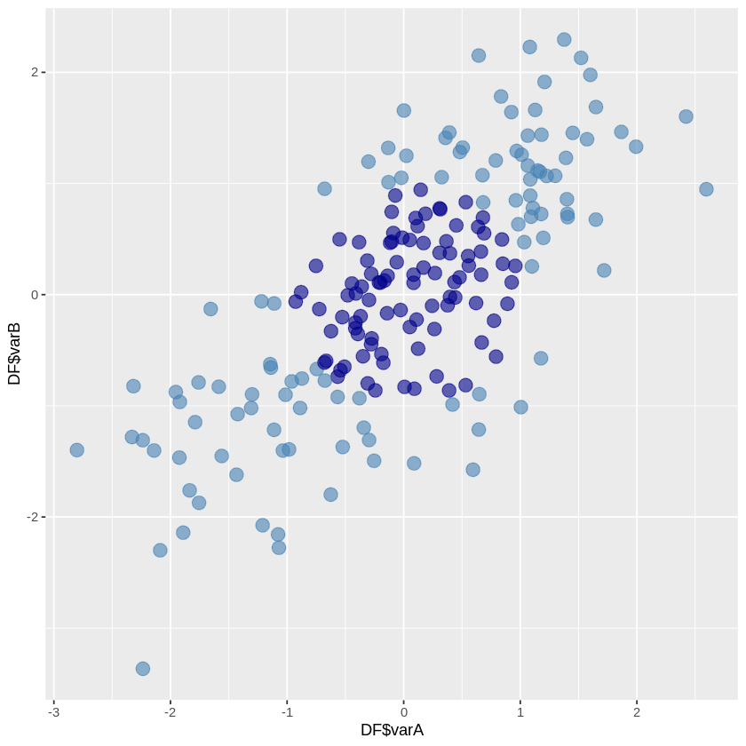

```python
ggplot() +
geom_point(aes(DF$varA, DF$varB),
            color=DF$ID, alpha=0.6, size=4)
```